Exercício 1

SUGESTÃO:  
O código do trabalho poderia terminar antes do início do trabalho de forma a melhorar a vizualização e organização

### 2. Análise Descritiva

*Toda a parte da análise descritiva, incluindo gráficos pertinentes.*

Definir-se-á uma estatística para podermos captar algum indício de que um Material Selante possui melhor desempenho do que os outros, sabendo que quanto mais dentes forem classificados com 0 ou 1, melhor será o Material, logo:

Seja $soma_{01i}$ definida como sendo a soma das contagens de classificações 0 ou 1 feita no i-ésimo material. Seja $somatotal_{i}$ igual ao total de dentes analisados por tipo de material, que pelo problema sabe-se que são setenta e dois. Essa estatística pode ser considerada uma proporção e visa identificar qual Material produz os casos de Maior interesse em relação ao problema, expressando-se os resultados numa porcentagem.

Logo,
$$soma_{01i}=\frac{soma_{0i}+soma_{1i}}{72}$$
para $i=1,2,3$

Portanto, para o material Allbond obteve-se
$$soma_{011}=\frac{soma_{01}+soma_{11}}{72}=\frac{9+18}{72}=\frac{27}{72}$$

Para Scotchbond,
$$soma_{013}=\frac{soma_{03}+soma_{13}}{72}=\frac{9+17}{72}=\frac{26}{72}$$

Logo, medindo esses resultados em porcentagem, temos que para Allbond 37,5 % das classificações estão alocadas entre 0 e 1. Utilizando mesmo raciocínio, para Optibond 83,33 % e, Scotchbond 36,11 %. Baseados nestes resultados, observa-se que o Selente Optibond possui maiores classificações situadas entre os menores níveis de microinfiltração, sugerindo que esse material tenha melhor desempenho que os outros. Vê-se também que os resultados para Allbond e Scotchbond são semelhantes porém, nenhuma conclusão pode ser aferida pois há de se observar aonde residem as maiores proporções de classificação, se entre o valor intermediário 2 ou nos valores mais extremos 3 e 4.

Na primeira destas, observa-se uma prevalecência das classificações em torno de 2, e a identificação com a segunda maior quantidade é a 1 , sugerindo que esse método tem níveis razoáveis de microinfiltração e talvez não seja o que proporciona os menores nívei.

Na segunda figura, especula-se a sua superioridade na retenção de microinfiltração pois constata-se visualmente que as maiores categorizações se situam nos valores de 0 e 1.

A terceira figura evidencia uma pior rotulamento em relacionado aos demais pois há maiores quantidades no valor de 3, e outras razoáveis entre 1 e 2, que sugerem um pior desempenho em relação aos outros métodos de selagem.

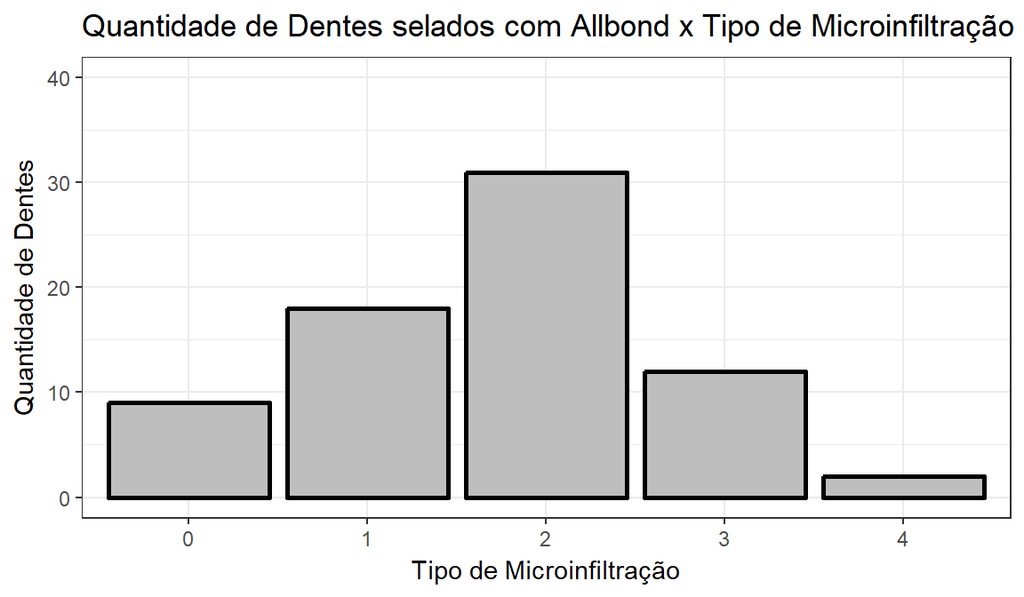

[figure not shown]

[figure not shown]

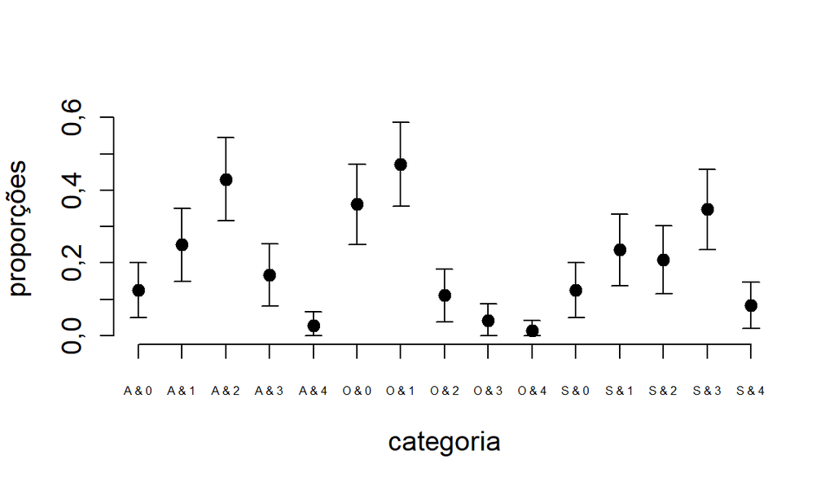

### 3. Análise Inferencial

*Objetivos: Descrição do(s) modelo(s), análise(s) de resíduo(s), comparações de interesse, gráficos e comentários (a escolha dos níveis de significância fica à cargo de cada equipe, devendo os valores adotadas, serem informados no relatório). Naturalmente, quando determinado, deverão ser usadas as metodologias constantes na questão. Caso a metodologia (modelo) usado não se adeque bem aos dados, comentários a respeito deverão ser feitos, mencionando que outras metodologias devem ser utilizadas (não, necessariamente, precisa ser dito qual(is)).*

O Modelo probabilistico gerador da Tabela é o Produto de Multinomiais Independentes pois os totais marginais relacionados aos tipos de materiais de Selante são fixados, portanto o modelo é dado pela seguinte equação:

$$N_{i}=(N_{i0},N_{i1},N_{i2},N_{i3},N_{i4})^{'}\sim multinomial(n_{i.},\mathbf{\theta}_{i}) \ \ i = 1,2,3$$

$N_i\perp N_j\ \forall\ i\neq j \ ;\ i,j=1,2,3$ , $\mathbf{{\theta_{i}}}=(\theta_{i0},\theta_{i1},\theta_{i2},\theta_{i3})^{'}$ e $\theta_{ij} \in (0,1)$

Medida de Desempenho:  
A medida de desempenho proposta foi a média dos escores ponderadas pela probabilidade de classificação em cada grupo. Temos então que as medidas de desempenho dos materiais são dadas por:

$\bar{S}_{Allbond} = 0\theta_{10} + 1\theta_{11} + 2\theta_{12} + 3\theta_{13} + 4\theta_{14}$  
$\bar{S}_{Optibond} = 0\theta_{20} + 1\theta_{21} + 2\theta_{22} + 3\theta_{23} + 4\theta_{24}$  
$\bar{S}_{Scotchbond} = 0\theta_{30} + 1\theta_{31} + 2\theta_{32} + 3\theta_{33} + 4\theta_{34}$

Temos o interesse em testar se as medidas de desempenho dos três materiais são iguais, ou seja, testar a hipóteses:

$$H_0: \left\{\begin{matrix}
\bar{S}_{Allbond} - \bar{S}_{Optibond} = 0\\
\bar{S}_{Allbond} - \bar{S}_{Scotchbond} = 0
\end{matrix}\right.\ Vs \ H_1: \textrm{Há\ pelo\ menos\ uma\ diferença}$$

A qual é equivalente a testar:

$$H_0 : \ B\pi = D\ \ Vs\ \ H_1 : B\pi \neq D$$

$$H_{01}: \bar{S}_{Allbond} - \bar{S}_{Optibond} = 0 \ Vs \ H_{11}: \bar{S}_{Allbond} - \bar{S}_{Optibond} \neq 0$$
A qual é equivalente a testar:

$$H_{01} : \ B_1\pi = D\ \ Vs\ \ H_{11} : B_1\pi \neq D$$
Os vetores $B_1$, $\pi$ e D estão definidos em anexo.

A partir do teste da hipótese acima, observou-se um valor de 30,42 que , respeitando-se os graus de liberdade da estatística do teste (“1” nesse caso), obtemos um p-valor de <0.0001

$$H_{02}: \bar{S}_{Allbond} - \bar{S}_{Scotchbond} = 0 \ Vs \ H_{12}: \bar{S}_{Allbond} - \bar{S}_{Scotchbond} \neq 0$$
A qual é equivalente a testar:

$$H_{02} : \ B_2\pi = D\ \ Vs\ \ H_{12} : B_2\pi \neq D$$
Os vetores $B_2$, $\pi$ e D estão definidos em anexo. A partir do teste da hipótese acima, observou-se um valor de 2,84 que , respeitando-se os graus de liberdade da estatística do teste (“1” nesse caso), obtemos um p-valor de 0,0919

$$H_{03}: \bar{S}_{Optibond} - \bar{S}_{Scotchbond} = 0 = 0 \ Vs \ H_{13}: \bar{S}_{Optibond} - \bar{S}_{Scotchbond} \neq 0$$
A qual é equivalente a testar:

$$H_{03} : \ B_3\pi = D\ \ Vs\ \ H_{13} : B_3\pi \neq D$$
Os vetores $B_3$, $\pi$ e D estão definidos em anexo.

Os vetores $B_2$, $\pi$ e D estão definidos em anexo. A partir do teste da hipótese acima, observou-se um valor de 44,21 que , respeitando-se os graus de liberdade da estatística do teste (“1” nesse caso), obtemos um p-valor de <0.0001.

Uma outra análise poderia ser feita a partir de um modelo de regressão linear para Tabela de Contingência, escrito na forma $A\pi =X\beta$.

Dados os resultados expostos anteriormente, podemos testar o ajuste de um modelo que leva em consideração a hipótese de que todos as medidas de desempenho dos materiais são diferentes, e partir desse modelo se obtem as estimativas para a medida de desempenho de cada material.

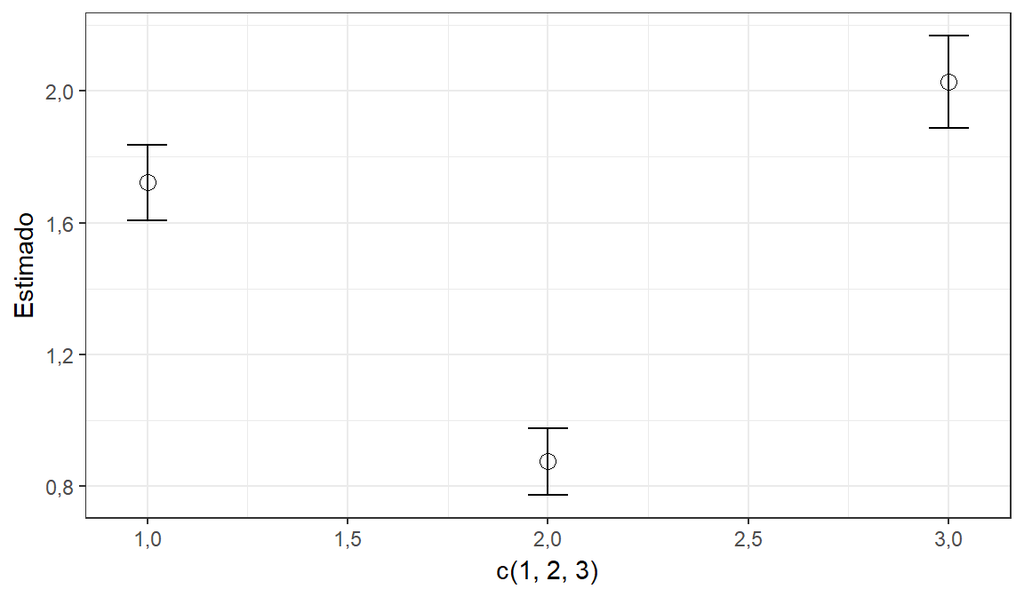

Note que, os intervalos de confiança para as medidas dos materiais Allbond e Scothbond, apesar de não ter nenhuma intersecção, são bem próximos, o que também indica a proximidade das medidas de desempenho destes materiais. O respectivo intervalo de confiança para o material Opitbond é vizualmente bem distante dos demais, o que nos indica um melhor desempenho deste, uma vez que observamos este intervalo abaixo dos demais.

### 5. Anexos

Para testar a hipótese
$$H_{01}: \bar{S}_{Allbond} - \bar{S}_{Optibond} = 0 \ Vs \ H_{11}: \bar{S}_{Allbond} - \bar{S}_{Optibond} \neq 0 \\
\leftrightarrow \\
H_{01} : \ B\pi = D\ \ Vs\ \ H_{11} : B\pi \neq D$$
definimos:
$$B_1^{'} =
\begin{bmatrix}
0 \\
1 \\
2 \\
3 \\
4 \\
0 \\
-1 \\
-2 \\
-3 \\
-4 \\
0 \\
0 \\
0 \\
0 \\
0
\end{bmatrix} \ ; \pi = \begin{bmatrix}
\theta_{10}\\
\theta_{11}\\
\theta_{12}\\
\theta_{13}\\
\theta_{14}\\
\theta_{20}\\
\theta_{21}\\
\theta_{22}\\
\theta_{23}\\
\theta_{24}\\
\theta_{30}\\
\theta_{31}\\
\theta_{32}\\
\theta_{33}\\
\theta_{34}
\end{bmatrix} \ e \ \ D = \begin{bmatrix}
0
\end{bmatrix}.$$

Para testar a hipótese:
$$H_{02}: \bar{S}_{Allbond} - \bar{S}_{Scotchbond} = 0 = 0 \ Vs \ H_{12}: \bar{S}_{Allbond} - \bar{S}_{Scotchbond} \neq 0 \\
\leftrightarrow \\
H_{02} : \ B\pi = D\ \ Vs\ \ H_{12} : B\pi \neq D$$

$$B_2^{'} =
\begin{bmatrix}
0 \\
1 \\
2 \\
3 \\
4 \\
0 \\
0 \\
0 \\
0 \\
0 \\
0 \\
-1 \\
-2 \\
-3 \\
-4
\end{bmatrix} \ ; \pi = \begin{bmatrix}
\theta_{10}\\
\theta_{11}\\
\theta_{12}\\
\theta_{13}\\
\theta_{14}\\
\theta_{20}\\
\theta_{21}\\
\theta_{22}\\
\theta_{23}\\
\theta_{24}\\
\theta_{30}\\
\theta_{31}\\
\theta_{32}\\
\theta_{33}\\
\theta_{34}
\end{bmatrix} \ e \ \ D = \begin{bmatrix}
0
\end{bmatrix}.$$

Para testar a hipótese:

$$H_{03}: \bar{S}_{Optibond} - \bar{S}_{Scotchbond} = 0 = 0 \ Vs \ H_{13}: \bar{S}_{Optibond} - \bar{S}_{Scotchbond} \neq 0 \\
\leftrightarrow \\ H_{03} : \ B\pi = D\ \ Vs\ \ H_{13} : B\pi \neq D$$

onde:

$$B_3^{'} =
\begin{bmatrix}
0 \\
0 \\
0 \\
0 \\
0 \\
0 \\
1 \\
2 \\
3 \\
4 \\
0 \\
-1 \\
-2 \\
-3 \\
-4
\end{bmatrix} \ ; \pi = \begin{bmatrix}
\theta_{10}\\
\theta_{11}\\
\theta_{12}\\
\theta_{13}\\
\theta_{14}\\
\theta_{20}\\
\theta_{21}\\
\theta_{22}\\
\theta_{23}\\
\theta_{24}\\
\theta_{30}\\
\theta_{31}\\
\theta_{32}\\
\theta_{33}\\
\theta_{34}
\end{bmatrix} \ e \ \ D = \begin{bmatrix}
0
\end{bmatrix}.$$

Para os modelos de regressão temos as seguintes hipóteses:

$$H_0: \left\{\begin{matrix}
\bar{S}_{Allbond} = \alpha_{1} \\
\bar{S}_{Optibond} = \alpha_{2} \\
\bar{S}_{Scotchbond} = \alpha_{3} \\
\end{matrix}\right.\ Vs \ H_1: \textrm{Há\ pelo\ menos\ uma\ diferença}$$